# Détection de valeurs aberrantes et imputation de données manquantes

Serge-Étienne Parent

1 mars 2019

## Objectifs spécifiques

À la fin de ce chapitre, vous

- saurez comment procéder à l’imputation de valeurs manquantes en mode univarié et multivarié
- saurez comment détecter des valeurs aberrantes en mode univarié et multivarié

## Données manquantes

Donnée:

- perdue lors de la collecte ou du processus d’enregistrement des données,
- non mesurée en raison du dysfonctionnement d’un équipement,
- écartée en raison d’une contamination,
- oubliée
- non étudiée

## Données manquantes

```r
iris_NA %>% sample_n(6)
```

```
##   Sepal.Length Sepal.Width Petal.Length Petal.Width    Species
## 1           NA         3.8          1.6         0.2     setosa
## 2          6.6         3.0           NA         1.4 versicolor
## 3          6.1         2.8          4.7         1.2 versicolor
## 4          5.5         4.2          1.4         0.2     setosa
## 5          5.0         3.5          1.6         0.6       <NA>
## 6          5.5         2.3          4.0         1.3 versicolor
```

## Données manquantes: biais

```r
iris_NA_biais_1
```

```
## # A tibble: 6 x 2
##   Sepal.Length Species
##          <dbl> <chr>
## 1          5.3 setosa
## 2         NA   versicolor
## 3          4.9 setosa
## 4         NA   versicolor
## 5          4.7 setosa
## 6         NA   versicolor
```

```r
mean(iris_NA_biais_1$Sepal.Length, na.rm = TRUE)
```

```
## [1] 4.966667
```

## Données manquantes: biais

```r
iris_NA_biais_2
```

```
## # A tibble: 6 x 2
##   Sepal.Length Species
##          <dbl> <chr>
## 1          5.3 setosa
## 2          7   versicolor
## 3          4.6 setosa
## 4          6.4 versicolor
## 5          4.8 setosa
## 6          6.9 versicolor
```

```r
mean(iris_NA_biais_2$Sepal.Length, na.rm = TRUE)
```

```
## [1] 5.833333
```

## Portrait des données manquantes: proportions

```r
iris_NA %>%
        group_by(Species) %>%
        summarise_each(funs(sum(is.na(.))/length(.)))
```

```
## # A tibble: 4 x 5
##   Species    Sepal.Length Sepal.Width Petal.Length Petal.Width
##   <fct>             <dbl>       <dbl>        <dbl>       <dbl>
## 1 setosa           0.114       0.0682       0.0682      0.0227
## 2 versicolor       0.0217      0.0870       0.0435      0.0870
## 3 virginica        0.0851      0.0638       0.0426      0.0426
## 4 <NA>             0           0            0.0769      0.0769
```

## Portrait des données manquantes: types de données manquantes

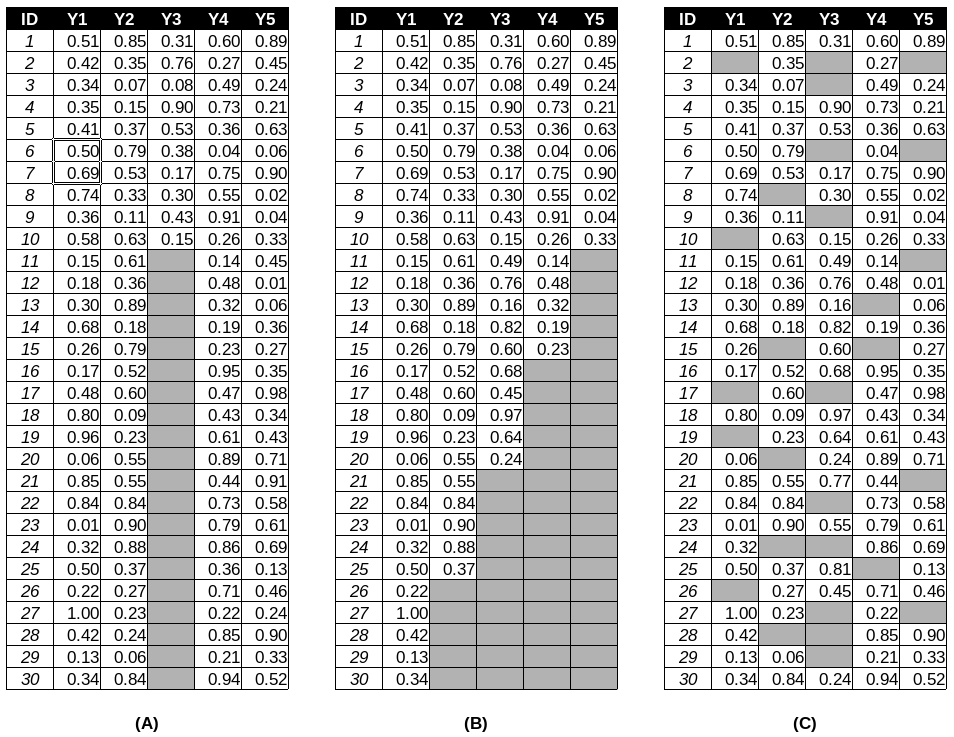

## Portrait des données manquantes: diagrammes (1/)

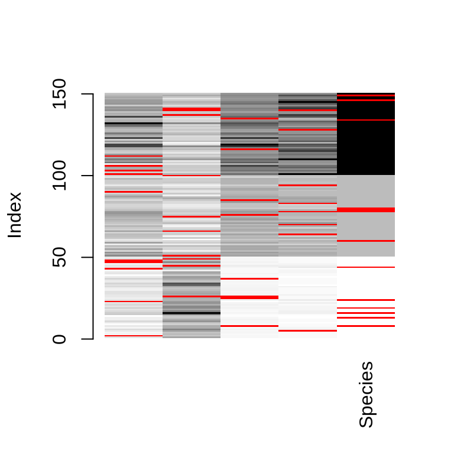

```r
VIM::matrixplot(iris_NA)
```

## Portrait des données manquantes: diagrammes (2/)

```
plot(VIM::aggr(iris_NA))
```

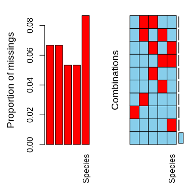

## Mécanismes des données manquantes

- Manquante complètement au hasard (MCAR). La probabilité d’absence est la même pour toutes les observations et ne dépend que de paramètres extérieurs indépendants de cette variable.
- Manquante au hasard (MAR). La probabilité de l’absence dépend de la valeur observée (univariée ou multivariée).
- Manquante non au hasard (MNAR). La probabilité qu’une valeur manque dépend d’une valeur non observée.

## Imputation

- Enlever les lignes où l’on trouve des données manquantes, ou bien des colonnes où l’on retrouve plusieurs données manquantes (MCAR)
- Remplacer par la moyenne (MCAR ou MAR)
- **Imputation multiple: modélisation en fonction des données présentes**

## Imputation multiple

Remplacer les données manquantes par une estimation basée sur les distributions et les relations entre les covariables présentes.

## Imputation multiple avec MICE (MCAR)

```r
iris_mice <- mice::mice(iris_NA, method = "rf") # rf pour random forest
iris_imp <- complete(iris_mice)
```

```
##     Sepal.Length Sepal.Width Petal.Length Petal.Width    Species
## 2             NA         3.0          1.4         0.2     setosa
## 5            5.0         3.6          1.4          NA     setosa
## 8            5.0         3.4           NA         0.2       <NA>
## 13           4.8         3.0          1.4         0.1       <NA>
## 16           5.7         4.4          1.5         0.4       <NA>
## 19           5.7         3.8          1.7         0.3       <NA>
## 23            NA         3.6          1.0         0.2     setosa
## 24           5.1         3.3          1.7         0.5       <NA>
## 25           4.8         3.4           NA         0.2     setosa
## 26           5.0          NA           NA         0.2     setosa
## 37           5.5         3.5           NA         0.2     setosa
## 43            NA         3.2          1.3         0.2     setosa
## 44           5.0         3.5          1.6         0.6       <NA>
## 45           5.1          NA          1.9         0.4     setosa
```

[output cut: 31 more lines]

```
##     Sepal.Length Sepal.Width Petal.Length Petal.Width    Species
## 2            5.5         3.0          1.4         0.2     setosa
## 5            5.0         3.6          1.4         0.1     setosa
## 8            5.0         3.4          1.3         0.2     setosa
## 13           4.8         3.0          1.4         0.1     setosa
## 16           5.7         4.4          1.5         0.4     setosa
## 19           5.7         3.8          1.7         0.3     setosa
## 23           4.4         3.6          1.0         0.2     setosa
## 24           5.1         3.3          1.7         0.5     setosa
## 25           4.8         3.4          1.3         0.2     setosa
## 26           5.0         3.2          1.5         0.2     setosa
## 37           5.5         3.5          1.5         0.2     setosa
## 43           4.7         3.2          1.3         0.2     setosa
## 44           5.0         3.5          1.6         0.6     setosa
## 45           5.1         3.1          1.9         0.4     setosa
```

[output cut: 31 more lines]

```
##     Sepal.Length Sepal.Width Petal.Length Petal.Width    Species
## 2            4.9         3.0          1.4         0.2     setosa
## 5            5.0         3.6          1.4         0.2     setosa
## 8            5.0         3.4          1.5         0.2     setosa
## 13           4.8         3.0          1.4         0.1     setosa
## 16           5.7         4.4          1.5         0.4     setosa
## 19           5.7         3.8          1.7         0.3     setosa
## 23           4.6         3.6          1.0         0.2     setosa
## 24           5.1         3.3          1.7         0.5     setosa
## 25           4.8         3.4          1.9         0.2     setosa
## 26           5.0         3.0          1.6         0.2     setosa
## 37           5.5         3.5          1.3         0.2     setosa
## 43           4.4         3.2          1.3         0.2     setosa
## 44           5.0         3.5          1.6         0.6     setosa
## 45           5.1         3.8          1.9         0.4     setosa
```

[output cut: 31 more lines]

## Données aberrantes

**Définition**. Un scalaire ou un vecteur qui semble non conforme en regard des autres scalaires ou vecteurs dont on dispose pour les autres observations de l’échantillon.

## Données aberrantes

**Conséquences**. Estimateurs de paramètres biaisés, puis interprétation ou prédiction erronée.

## Origine des donnes aberrantes

- la variabilité inhérente mais inusitée
- erreur méthodologique
- erreur d’exécution (ou de transcription)

## Examiner la distribution

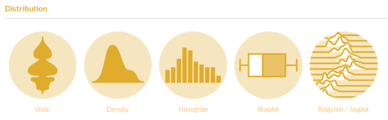

Source: [R graph gallery](https://www.r-graph-gallery.com/)

## Distribution

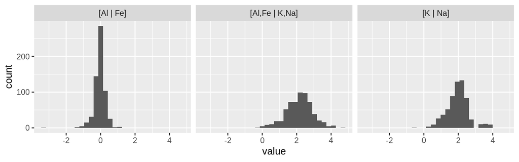

```r
ilr_elements %>%
  gather("balance", "value") %>%
  ggplot(aes(x = value)) +
  geom_histogram(bins = 30) +
  facet_grid(. ~ balance)
```

## Bivarié

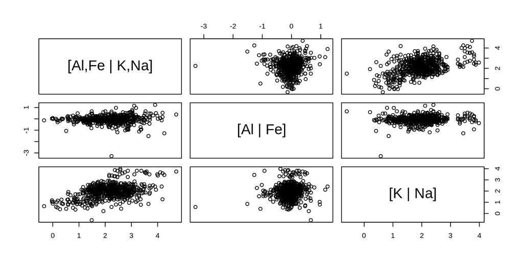

```r
plot(ilr_elements)
```

## Méthodes

Basées sur la distance

- Distance de Mahalanobis
- Distance de Mahalanobis robuste sur les PCA robustes

Basées sur le nombre de points

- Minimisation du volume minimum de l’ellipsoïde (MVE)
- Minimisation du déterminant - indicateur de dispersion (MCD)

## MVE et MCD

```r
library("MASS")
select <- dplyr::select # pour éviter que la fonction select du module MASS remplace celle de dplyr
min_in <- round(0.9 * nrow(ilr_elements)) # le minimum de points à garder, 90% du total
id_in <- cov.mve(ilr_elements, quantile.used = min_in)$best
is_in <- 1:nrow(ilr_elements) %in% id_in
```

## MVE et MCD

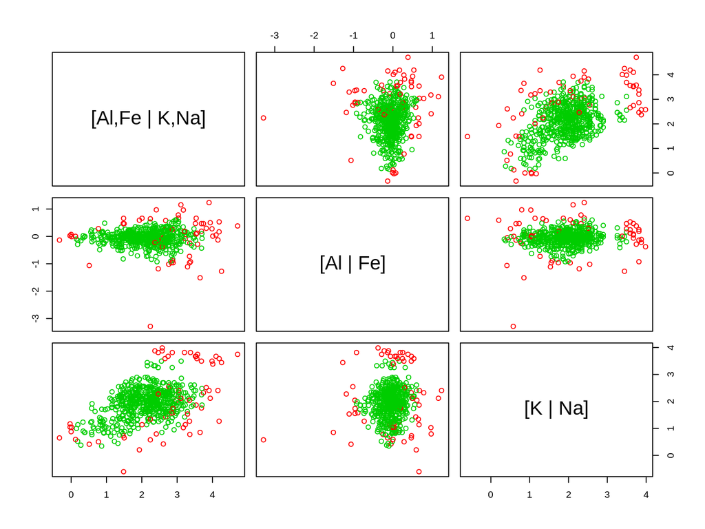

```r
plot(ilr_elements, col = is_in + 2)
```

## MVE et MCD

```r
sum(!is_in) / length(is_in)
```

```
## [1] 0.1004862
```

## Distance

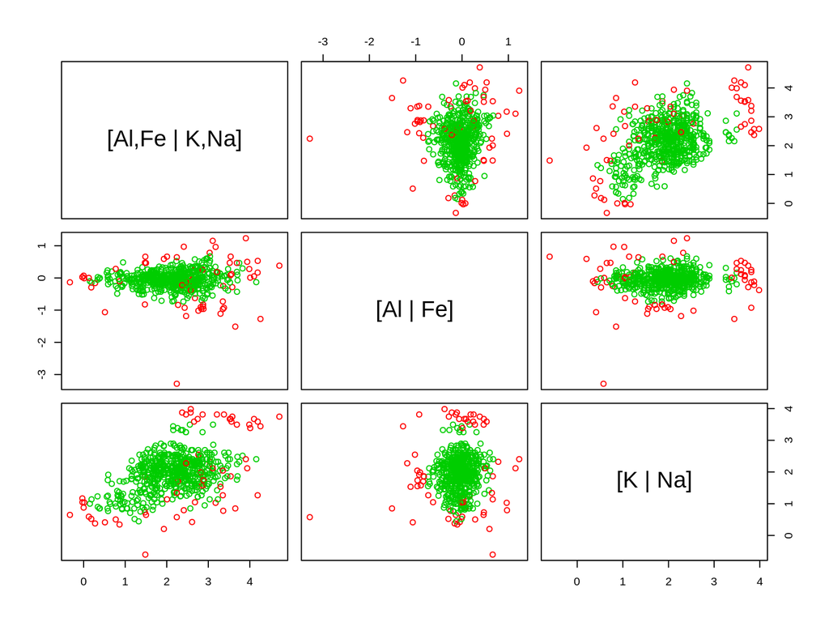

```r
is_out <- sign2(ilr_elements, qcrit = 0.975)$wfinal01 # sign1 pour la distance de Mahalanobis
plot(ilr_elements, col = is_out + 2)
```

## Distance

```r
sum(is_out == 0) / length(is_out)
```

```
## [1] 0.102107
```

## Et alors?

- Les méthodes MVE et MCD sont peu adaptées au distributions assymétriques.
- La méthode `sign1` suppose une distribution multinormale.
- La méthode `sign2` est robuste et s’applique sur divers types de distributions.

## Attention

Une donnée aberrante n’est pas nécessairement une mauvaise donnée.

## Objectifs spécifiques

À la fin de ce chapitre, vous

- saurez comment procéder à l’imputation de valeurs manquantes en mode univarié et multivarié
- saurez comment détecter des valeurs aberrantes en mode univarié et multivarié